## Report: act_report

# Twitter Analytics: “WeRateDogs”

[figure not shown]

WeRateDogs is a Twitter account that rates people’s dogs with humorous comments.The dataset is gotten from the tweet archive of Twitter user @dog_rates, an additional data from Twitter API and an image prdiction file gotten from a neural network.

## Insights and Visualization

The data has been gathered, assessed, cleaned, stored and has been analyzed. some research questions were asked and answered, below are the findings.

### Question 1: What are the top 10 most common dog breed

From the chart, we can see the 10 most common dog breed with the Golden Retriever championing the list. These dogs have most tweets on them, which has led them on our most common list.

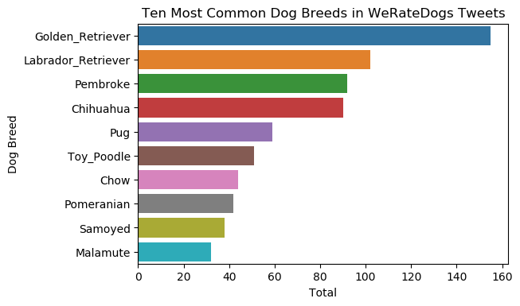

Below is an image of the Golden retriever which is the most common dog breed that is uploaded to WeRateDogs twitter page for rating.

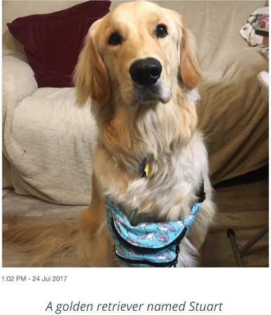

### Question 2: What are the top 10 dog breeds with highest likes.

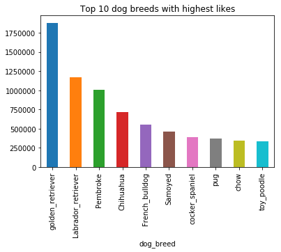

The golden_retriever is also the breed with the most likes. With this particular breed being the most common, it is only natural for it to also be the breed with the most engagement on WeRateDogs page. I mean are they so cute and lovable. While, the toy poodle completes the dog breed with the highest likes.

### Question 3: What are the top 10 dog breeds with highest retweets.

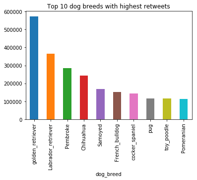

The golden retriever is also the breed with the most retweets, Labrador Retriever comes in second highest. While, the Pomeranian concludes the top 10 dog breeds with highest retweets.